# Lab 3: COVID-19

Ecosystem Science and Sustainability 330

Author

https://github.com/SarahRoseCulhane

**question 1: Public Data**

```r
library(tidyverse); library(flextable)
data = read_csv('https://raw.githubusercontent.com/nytimes/covid-19-data/master/us-counties.csv')
```

Here is how I created an object called my.date set as “2022-02-01” and an object called my.state, set as “Colorado”

```r
my.date <- as.Date("2022-02-01")
my.state <- "Colorado"
```

**Question 2: Daily Summary**

Here, I created a subset limiting the data to Colorado and adding new columns for new cases and new deaths

```r
colorado_covid <- data %>%
  filter(state == my.state) %>%
  arrange(county, date) %>%
  group_by(county) %>%
  mutate(
    new_cases = cases - lag(cases, default = 0),
    new_deaths = deaths - lag(deaths, default = 0)
  ) %>%
  ungroup()
```

Here is the code I used to generate a data set of the 5 counties with the most cumulative cases.

```r
covid_most_cumulative <- colorado_covid %>%
  filter(date == my.date) %>%
  arrange(desc(cases)) %>%
  slice_head(n = 5) %>%
  select(county, cases)
```

Here is the code I used to make a table of the data using the flextable function.

```r
covid_most_cumulative_table <- flextable(covid_most_cumulative) %>%
  add_footer_lines("Top 5 counties in Colorado with the most cumulative COVID cases on 2022-02-01") %>%
  set_caption("Table 1: Most cumulative COVID cases") %>%
  set_table_properties(layout = "autofit", width = 0.5) %>%
  align(align = "center", part = "all")

covid_most_cumulative_table
```

| county | cases |
| --- | --- |
| El Paso | 170,673 |
| Denver | 159,022 |
| Arapahoe | 144,255 |
| Adams | 126,768 |
| Jefferson | 113,240 |

Top 5 counties in Colorado with the most cumulative COVID cases on 2022-02-01

Here is the code I used to generate a table showing the top 5 counties with the most new cases

```r
covid_new_cases <- colorado_covid %>%
  filter(date == my.date) %>%
  select (county, new_cases) %>%
  arrange(desc(new_cases)) %>%
  slice_head(n = 5)
```

Here is the code I used to generate a table of the data using flextable

```r
covid_new_cases_table <- flextable(covid_new_cases) %>%
  add_footer_lines("Top 5 counties in Colorado with the most new cases on 2022-02-01") %>%
  set_caption("Table 2: Most new COVID cases") %>%
  set_table_properties(layout = "autofit", width = 0.5) %>%
  align(align = "center", part = "all")
covid_new_cases_table
```

| county | new_cases |
| --- | --- |
| El Paso | 630 |
| Arapahoe | 401 |
| Denver | 389 |
| Adams | 326 |
| Jefferson | 291 |

Top 5 counties in Colorado with the most new cases on 2022-02-01

**Question 3: Normalizing Data** I used the code to complete the following tasks:

I used the following code to read the population data

```r
pop_url <- 'https://www2.census.gov/programs-surveys/popest/datasets/2020-2023/counties/totals/co-est2023-alldata.csv'
```

First, I renamed the “fips” column “FIP” in the covid data

```r
colorado_covid_temp <- colorado_covid %>%
  rename(FIP = fips)
colorado_covid_temp
```

```
# A tibble: 49,527 × 8
   date       county state    FIP   cases deaths new_cases new_deaths
   <date>     <chr>  <chr>    <chr> <dbl>  <dbl>     <dbl>      <dbl>
 1 2020-03-12 Adams  Colorado 08001     2      0         2          0
 2 2020-03-13 Adams  Colorado 08001     3      0         1          0
 3 2020-03-14 Adams  Colorado 08001     6      0         3          0
 4 2020-03-15 Adams  Colorado 08001     6      0         0          0
 5 2020-03-16 Adams  Colorado 08001     8      0         2          0
 6 2020-03-17 Adams  Colorado 08001    10      0         2          0
 7 2020-03-18 Adams  Colorado 08001    10      0         0          0
 8 2020-03-19 Adams  Colorado 08001    10      0         0          0
 9 2020-03-20 Adams  Colorado 08001    12      0         2          0
10 2020-03-21 Adams  Colorado 08001    14      0         2          0
# ℹ 49,517 more rows
```

Then, I loaded the population data

```r
population_data = read_csv('https://www2.census.gov/programs-surveys/popest/datasets/2020-2023/counties/totals/co-est2023-alldata.csv')
```

I used the following code to: - Converted the STATE numeric into a character forced to 2 digits with a leading 0 (when needed) - Converted the COUNTY numeric into a character forced to 3 digits with leading 0’s (when needed) - Created a FIP variable the STATE numeric into a character forced to 2 digits with a leading 0 (when needed)

```r
population_data$STATE_FIP <- sprintf("%02s", population_data$STATE)
population_data$COUNTY_FIP <- sprintf("%03s", population_data$COUNTY)

population_data$FIP <- paste0(population_data$STATE_FIP, population_data$COUNTY_FIP)
```

Here is the code I used to select only columns that contain “NAME” or “2021” and remove counties with FIP code “000”

```r
population_data_2021 <- population_data %>%
  filter(COUNTY_FIP !="000", STNAME == my.state) %>%
   select(contains("NAME") | contains("2021"), FIP)
```

Here is the code I used to find the range of populations in Colorado counties in 2021. The range was between 741 and 737287 people

```r
range(population_data_2021$POPESTIMATE2021)
```

```
[1]    741 737287
```

```r
colorado_covid_2021 <- colorado_covid_temp %>%
  filter(date == my.date) %>%
  select(everything())
```

Here, joined colorado_covid_2021 and poulation_data_2021

```r
per_capita_2021 <- colorado_covid_2021 %>%
  left_join(population_data_2021, by = "FIP")
```

Here, I calculated per capita cumulative cases, per capita new cases, and per capita new deaths

```r
per_capita_2021 <- per_capita_2021 %>%
  mutate(
    per_capita_cumulative_cases = cases / POPESTIMATE2021,
    per_capita_new_cases = new_cases / POPESTIMATE2021,               per_capita_new_deaths = new_deaths / POPESTIMATE2021)
```

However, it looks like there are a lot of duplicates, so here is the code I used to clean up the dataset.

```r
per_capita_2021_clean <- per_capita_2021 %>%
  distinct()
```

Here is the code I used calculate the total per capita new cases and total per capita new cases, and per capita cumulative cases per county

```r
per_capita_county_summary <- per_capita_2021_clean %>%
  group_by(county) %>%
  summarize(
    total_cumulative_cases_per_capita = sum(per_capita_cumulative_cases, na.rm = TRUE),
    total_new_cases_per_capita = sum(per_capita_new_cases, na.rm = TRUE),
    total_new_deaths_per_capita = sum(per_capita_new_deaths, na.rm = TRUE))
```

Here is the code I used to generate a table with the most cumulative cases per capita

```r
per_capita_county_summary_table <- per_capita_county_summary %>%
  select (county, total_cumulative_cases_per_capita) %>%
  arrange(desc(total_cumulative_cases_per_capita)) %>%
  slice_head(n = 5)

per_capita_county_summary_table <- flextable(per_capita_county_summary_table) %>%
  add_footer_lines("Top 5 counties in Colorado with the most cumulative cases per capita on 2022-02-01") %>%
  set_caption("Table 3: cumulative cases per capita") %>%
  set_table_properties(layout = "autofit", width = 0.5) %>%
  align(align = "center", part = "all")
per_capita_county_summary_table
```

| county | total_cumulative_cases_per_capita |
| --- | --- |
| Crowley | 0.5117698 |
| Bent | 0.4118749 |
| Pitkin | 0.3429659 |
| Lincoln | 0.3424082 |
| Logan | 0.3047701 |

Top 5 counties in Colorado with the most cumulative cases per capita on 2022-02-01

```r
per_capita_county_new_cases <- per_capita_county_summary %>%
  select (county, total_new_cases_per_capita) %>%
  arrange(desc(total_new_cases_per_capita)) %>%
  slice_head(n = 5)

per_capita_county_new_cases <-  flextable(per_capita_county_new_cases) %>%
  add_footer_lines("Top 5 counties in Colorado with the most new cases per capita on 2022-02-01") %>%
  set_caption("Table 3: new cases per capita") %>%
  set_table_properties(layout = "autofit", width = 0.5) %>%
  align(align = "center", part = "all")
per_capita_county_new_cases
```

| county | total_new_cases_per_capita |
| --- | --- |
| Crowley | 0.009764603 |
| Bent | 0.004120622 |
| Sedgwick | 0.003869304 |
| Washington | 0.002875924 |
| Las Animas | 0.002651039 |

Top 5 counties in Colorado with the most new cases per capita on 2022-02-01

**Question 5**

I could not figure out how to answer the question.

**Question 6**

Here is the code I used to 1. filter the data to the four states of interest and and calculate the number of daily new cases and the 7-day rolling mean 2. Make a facet plot of the data.

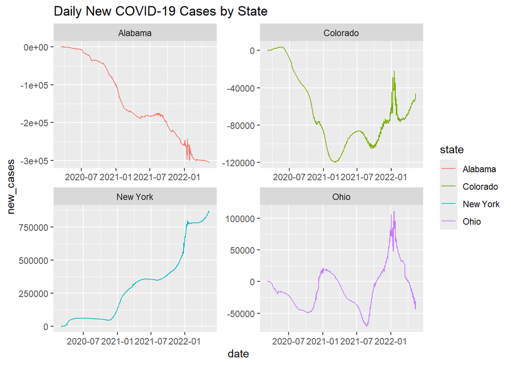

```r
covid_all_states <- data %>%
    arrange(county, date) %>%
    group_by(county) %>%
    mutate(
        new_cases = cases - lag(cases, default = 0),
        new_deaths = deaths - lag(deaths, default = 0)
     ) %>%
     ungroup()

state_data <- covid_all_states %>%
  filter(state %in% c("New York", "Colorado", "Alabama", "Ohio")) %>%
  group_by(state, date) %>%
  summarise(new_cases = sum(new_cases)) %>%
  mutate(rolling_avg = zoo::rollmean(new_cases, 7, fill = NA, align = "right"))
ggplot(state_data, aes(x = date, y = new_cases, color = state)) +
  geom_line() +
  facet_wrap(~ state, scales = "free") +
  labs(title = "Daily New COVID-19 Cases by State")
```

I could not figure out the last part of this question.

**Question 7**

Here is the code I used to calculate the Weighted Mean Center of the COVID-19 outbreak in the USA. I am not sure why the points are not on the map. I tried to filter it to just the longitude and latitude of the USA but I could not get that to work.

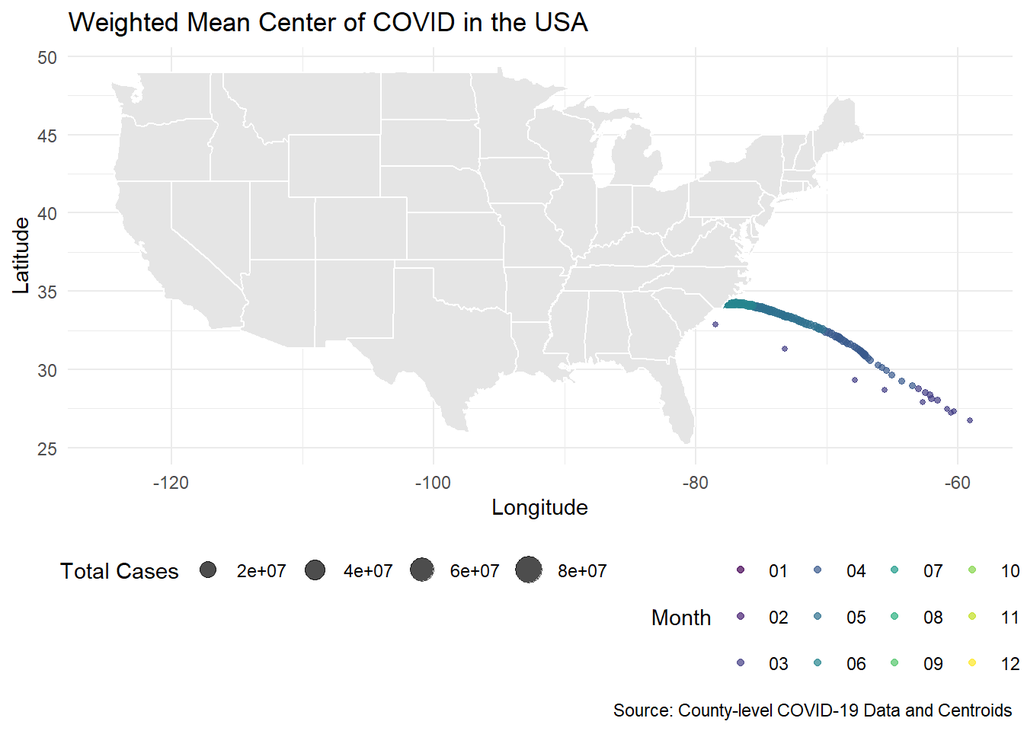

```r
county_centroids <- read_csv('https://raw.githubusercontent.com/mikejohnson51/csu-ess-330/refs/heads/main/resources/county-centroids.csv')
data_temp <- data %>%
  mutate(month = format(as.Date(date), "%m"))

county_centroids_joined <- data_temp %>%
  left_join(county_centroids, by = "fips")

weighted_mean_center <- county_centroids_joined %>%
  group_by(date) %>%
  summarise(
    total_cases = sum(cases, na.rm = TRUE),
    weighted_LON = sum(LON * cases, na.rm = TRUE) / total_cases,
    weighted_LAT = sum(LAT * cases, na.rm = TRUE) / total_cases
  )

ggplot(weighted_mean_center, aes(x = weighted_LON, y = weighted_LAT, color = factor(format(as.Date(date), "%m")), size = total_cases)) +
  geom_point(alpha = 0.7) +
  borders("state", fill = "gray90", colour = "white") +
  scale_color_viridis_d() +
  labs(title = "Weighted Mean Center of COVID in the USA",
       x = "Longitude", y = "Latitude",
       color = "Month", size = "Total Cases",
       caption = "Source: County-level COVID-19 Data and Centroids") +
  theme_minimal() +
  theme(legend.position = "bottom")
```